# Project 1

## Visualisation

```python
import matplotlib.pyplot as plt
```

Have a look at https://pandas.pydata.org/pandas-docs/stable/timeseries.html

Have you noticed that column `timestamp` in our data is a string? We have to convert it to pandas.Timestamp to be able to plot measurements correctly.

https://pandas.pydata.org/pandas-docs/stable/generated/pandas.to_datetime.html

```python
%time data['ts'] = pd.to_datetime(data.timestamp)
data.ts.describe()
```

```
CPU times: user 8.27 s, sys: 77.6 ms, total: 8.35 s
Wall time: 8.62 s
```

```
count                   56570
unique                  29779
top       2014-12-23 03:55:00
freq                        8
first     2014-12-15 01:40:00
last      2015-06-05 04:15:00
Name: ts, dtype: object
```

If it takes too long time to convert, try to help pandas and define time format you are reading:

https://docs.python.org/3/library/datetime.html#strftime-and-strptime-behavior

Be advised that you may want to `data.set_index('ts')` and use non unique index but there will be a performance penalty: https://stackoverflow.com/a/16629125

Now you can easily plot all measurements from some location and from some period of time.

For example: average temperature at *Fitzroy Gardens* only from 2014.

```
board 508
18.7
2014-12-20 20:05:00
board 505
18.7
2014-12-20 15:40:00
board 507
18.1
2014-12-20 15:45:00
board 502
17.4
2014-12-20 16:20:00
board 501
17.7
2014-12-20 15:45:00
```

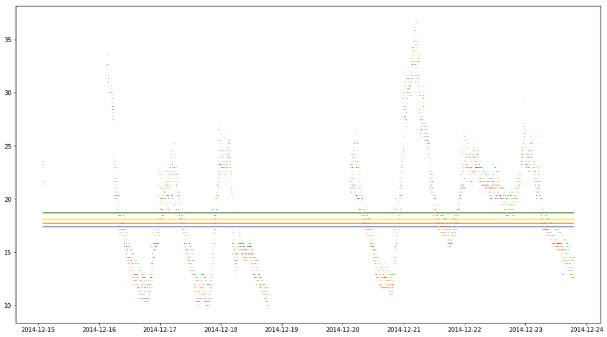

```python
# model

location_filter = data.location == 'Fitzroy Gardens'
time_filter = data.ts < pd.Timestamp('2015-01-01')
data_filtered = data[location_filter & time_filter]
boards = data_filtered.boardid.unique()

board_colors = ['#e6194B', '#3cb44b','#ffe119', '#4363d8', '#f58231', '#911eb4', '#42d4f4', '#f032e6']
board_color_index = 0


plt.figure(figsize=(18,10))

for board in boards:
    median_temp = median(data_filtered[data_filtered.boardid == board].temp_avg)
    median_time = data_filtered[data_filtered.boardid == board].ts
    median_time_dates = sorted(median_time)
    median_time_dates = median_time_dates[len(median_time_dates)//2]


    #board data for debugging
    print('board', board)
    print(median_temp)
    print(median_time_dates)

    plt.plot(data_filtered[data_filtered.boardid == board].ts, data_filtered[data_filtered.boardid == board].temp_avg, ',', c=board_colors[board_color_index], alpha=0.9)


    plt.hlines(median_temp, min(data_filtered[data_filtered.boardid == board].ts), max(data_filtered[data_filtered.boardid == board].ts), colors=board_colors[board_color_index], linestyles='solid')
    board_color_index+=1

plt.show()
```

Can you color separate different boards?

Can your plot the median?